# Practical machine learning Course Project

Vadim

October, 08 2017

## Background

The goal of this project is to predict the manner in which they performed the exercise and machine learning classification of accelerometers data on the belt, forearm, arm, and dumbell of 6 participants.In training data “classe” is the outcome variable in the training set using predictor variables to predict 20 different test cases.The data for this project come from this source is: http://groupware.les.inf.puc-rio.br/har.

The “classe” variable which classifies the correct and incorrect outcomes of A, B, C, D, and E categories. Six young health participants were asked to perform one set of 10 repetitions of the Unilateral Dumbbell Biceps Curl in five different fashions: exactly according to the specification (Class A), throwing the elbows to the front (Class B), lifting the dumbbell only halfway (Class C), lowering the dumbbell only halfway (Class D) and throwing the hips to the front (Class E).

### Libraries

```r
invisible(library(AppliedPredictiveModeling))
invisible(library(rpart))
invisible(library(rpart.plot))
invisible(library(rattle))
invisible(library(ElemStatLearn))
invisible(library(pgmm))
invisible(library(caret))
invisible(library(e1071))
invisible(library(gbm))
invisible(library(randomForest))
invisible(library(plyr))
```

## Loading the dataset

```r
setwd("C:/Users/Vadim/Desktop/DataScience_course/Practical machine learning/CourseProject")
# Download and reading the training data
download.file(url = "http://d396qusza40orc.cloudfront.net/predmachlearn/pml-training.csv",
              destfile = "./pml-training.csv")
train <- read.csv("./pml-training.csv", na.strings=c("NA","#DIV/0!",""))
# Download and reading the testing data
download.file(url = "http://d396qusza40orc.cloudfront.net/predmachlearn/pml-testing.csv",
              destfile = "./pml-testing.csv")
test <- read.csv("./pml-testing.csv", na.strings=c("NA","#DIV/0!",""))
```

## Cleaning the dataset

```r
# Use only variables used in testing cases.
useful <- names(test[,colSums(is.na(test)) == 0])[8:59]
train <- train[,c(useful,"classe")]
test <- test[,c(useful,"problem_id")]
```

## Subsetting the dataset

We will split our data into a training data set (60%) and a testing data set (40%)

```r
set.seed(12345)
inTrain <- createDataPartition(train$classe, p=0.6, list=FALSE)
training <- train[inTrain,]
testing <- train[-inTrain,]
```

## Desision tree model

Try to using Decision Tree.

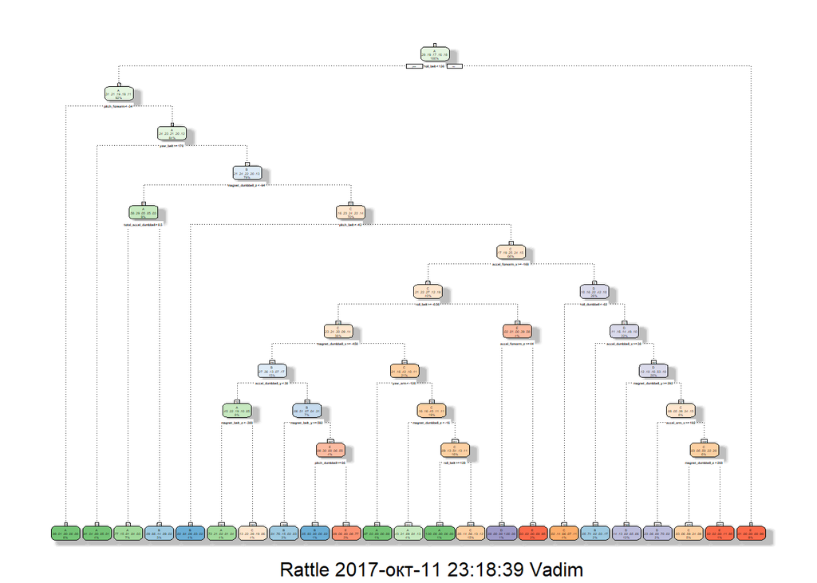

```r
#Training the model
modFitDT <- rpart(classe ~ ., data = training, method="class",
                  control = rpart.control(method = "cv", number = 10))
fancyRpartPlot(modFitDT)
```

```r
#Predictiong with the model
prediction <- predict(modFitDT, testing, type = "class")
confusionMatrix(prediction, testing$classe)
```

```
## Confusion Matrix and Statistics
##
##           Reference
## Prediction    A    B    C    D    E
##          A 1879  260   30   69   66
##          B   56  759   88   34   54
##          C  105  340 1226  354  234
##          D  155  132   23  807   57
##          E   37   27    1   22 1031
##
## Overall Statistics
##
##                Accuracy : 0.7267
##                  95% CI : (0.7167, 0.7366)
##     No Information Rate : 0.2845
##     P-Value [Acc > NIR] : < 2.2e-16
##
##                   Kappa : 0.6546
##  Mcnemar's Test P-Value : < 2.2e-16
##
## Statistics by Class:
##
##                      Class: A Class: B Class: C Class: D Class: E
## Sensitivity            0.8418  0.50000   0.8962   0.6275   0.7150
## Specificity            0.9243  0.96334   0.8405   0.9441   0.9864
## Pos Pred Value         0.8155  0.76589   0.5427   0.6874   0.9222
## Neg Pred Value         0.9363  0.88928   0.9746   0.9282   0.9389
## Prevalence             0.2845  0.19347   0.1744   0.1639   0.1838
## Detection Rate         0.2395  0.09674   0.1563   0.1029   0.1314
## Detection Prevalence   0.2937  0.12631   0.2879   0.1496   0.1425
## Balanced Accuracy      0.8831  0.73167   0.8684   0.7858   0.8507
```

Accuracy is not very high, 72%.

## Random forest model

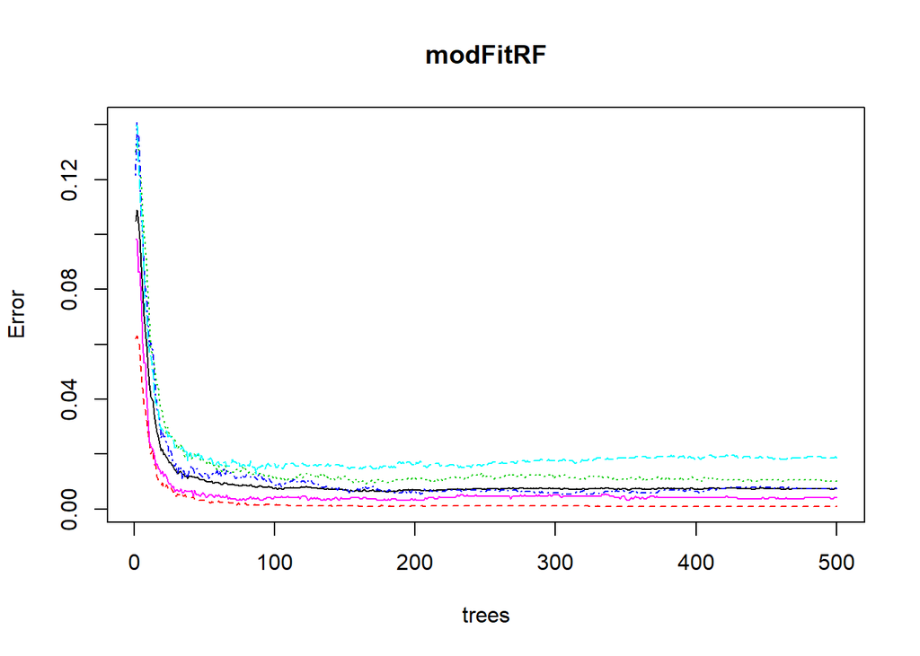

```r
#Training the model
modFitRF <- randomForest(classe ~ ., data = training, method = "rf", importance = T, trControl = trainControl(method = "cv", classProbs=TRUE,savePredictions=TRUE,allowParallel=TRUE, number = 10))
plot(modFitRF)
```

```r
#Predicting wit the model
prediction <- predict(modFitRF, testing, type = "class")
confusionMatrix(prediction, testing$classe)
```

```
## Confusion Matrix and Statistics
##
##           Reference
## Prediction    A    B    C    D    E
##          A 2229    8    0    0    0
##          B    3 1506    6    0    0
##          C    0    4 1362   16    2
##          D    0    0    0 1268    5
##          E    0    0    0    2 1435
##
## Overall Statistics
##
##                Accuracy : 0.9941
##                  95% CI : (0.9922, 0.9957)
##     No Information Rate : 0.2845
##     P-Value [Acc > NIR] : < 2.2e-16
##
##                   Kappa : 0.9926
##  Mcnemar's Test P-Value : NA
##
## Statistics by Class:
##
##                      Class: A Class: B Class: C Class: D Class: E
## Sensitivity            0.9987   0.9921   0.9956   0.9860   0.9951
## Specificity            0.9986   0.9986   0.9966   0.9992   0.9997
## Pos Pred Value         0.9964   0.9941   0.9841   0.9961   0.9986
## Neg Pred Value         0.9995   0.9981   0.9991   0.9973   0.9989
## Prevalence             0.2845   0.1935   0.1744   0.1639   0.1838
## Detection Rate         0.2841   0.1919   0.1736   0.1616   0.1829
## Detection Prevalence   0.2851   0.1931   0.1764   0.1622   0.1832
## Balanced Accuracy      0.9986   0.9953   0.9961   0.9926   0.9974
```

The random forest model performed well with accuracy 99%.

## Boosting model

```r
#Training the model
modFitBoost <- train(classe ~ ., method = "gbm", data = training,
                    verbose = F, trControl = trainControl(method = "cv", number = 10))
modFitBoost
```

```
## Stochastic Gradient Boosting
##
## 11776 samples
##    52 predictor
##     5 classes: 'A', 'B', 'C', 'D', 'E'
##
## No pre-processing
## Resampling: Cross-Validated (10 fold)
## Summary of sample sizes: 10599, 10599, 10598, 10600, 10598, 10597, ...
## Resampling results across tuning parameters:
##
##   interaction.depth  n.trees  Accuracy   Kappa
##   1                   50      0.7524630  0.6863880
##   1                  100      0.8202253  0.7723788
##   1                  150      0.8523247  0.8131110
##   2                   50      0.8509669  0.8111465
##   2                  100      0.9040427  0.8785431
##   2                  150      0.9296024  0.9109022
##   3                   50      0.8978435  0.8706881
##   3                  100      0.9405569  0.9247763
##   3                  150      0.9581336  0.9470296
##
## Tuning parameter 'shrinkage' was held constant at a value of 0.1
##
## Tuning parameter 'n.minobsinnode' was held constant at a value of 10
## Accuracy was used to select the optimal model using  the largest value.
## The final values used for the model were n.trees = 150,
##  interaction.depth = 3, shrinkage = 0.1 and n.minobsinnode = 10.
```

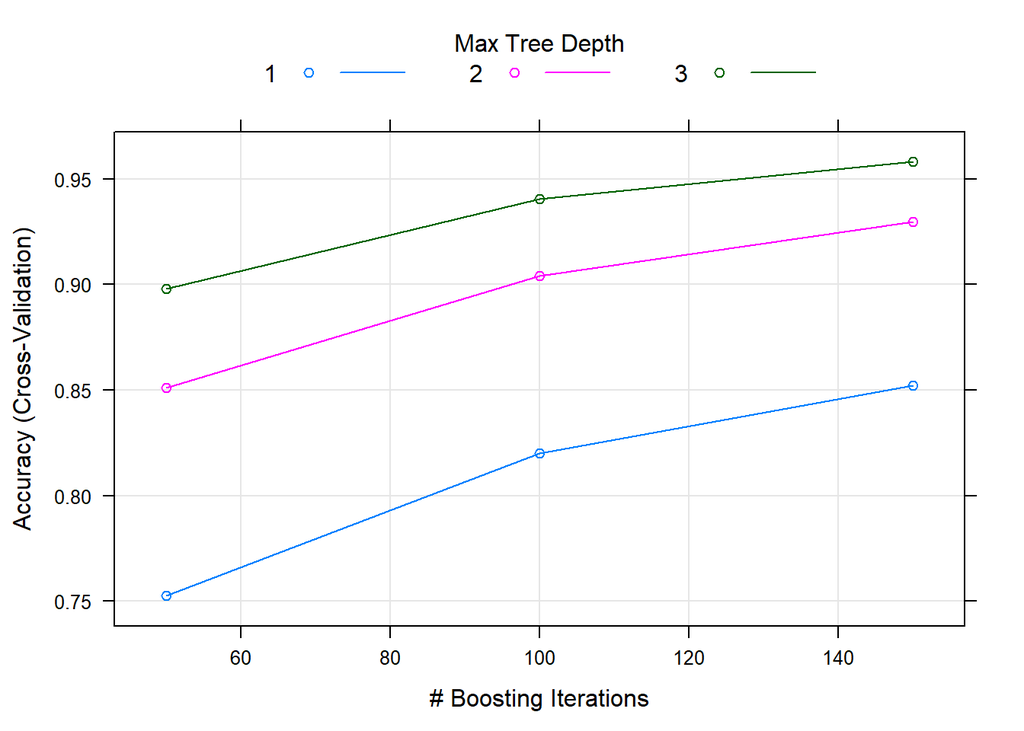

```r
plot(modFitBoost)
```

```r
#Predicting wit the model
prediction <- predict(modFitBoost, testing)
```

## Predicting on the test sample

```r
#Random forest
predictionRF <- predict(modFitRF, test)
predictionRF
```

```
##  1  2  3  4  5  6  7  8  9 10 11 12 13 14 15 16 17 18 19 20
##  B  A  B  A  A  E  D  B  A  A  B  C  B  A  E  E  A  B  B  B
## Levels: A B C D E
```

```r
#Boosting
predictionBoost <- predict(modFitBoost, test)
predictionBoost
```

```
##  [1] B A B A A E D B A A B C B A E E A B B B
## Levels: A B C D E
```